# Statistisk Analys: Laboration 3

Ottilia Andersson & David Sermoneta

2025-01-05

# Sammanfattning

I den här laborationen har vi undersökt jordens medeltemperatur. I uppgift 1 undersökte vi data för åren 1850-2007 och utförde linjär regression. Vi såg att det rådde viss tvekan kring hur bra det var med juts en linjär modell. I uppgift 2 undersökte vi samma data, men vi delade upp den i tre mindre tidsperioder. Vi såg att linjär anpassning fungerade bra för perioden 1970-2007 men sämre för de andra perioderna som vi tittade på. Vi hypotestestade och kom fram till att jorden går mot ett varmare klimat. I uppgift 3 gjorde vi prediktioner för jordens medeltemperatur åren 2008-2022, baserat på olika dataset, och jämförde med de faktiska värdena på jordens medeltemperatur dessa år. Vi kom fram till att det är svårt att göra prediktioner.

# Uppgift 1: Jordens medeltemperatur 1850-2007

Vi läser in fil med information om jordens medeltemperatur åren 1850-2007.

```r
df <- read.csv("temperatur.csv", header = TRUE) # Läser in jordens medeltemperatur 1850-2007
```

Vi visualiserar vår inlästa data i en scatterplot för att få en överblick över den:

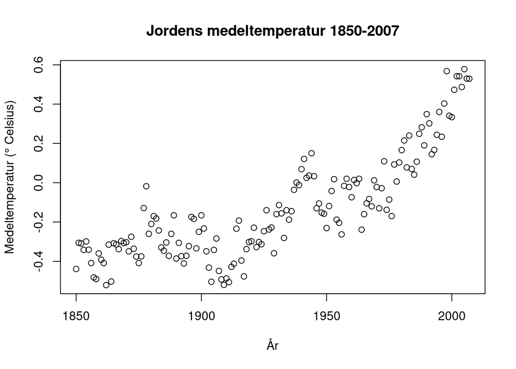

Jordens medeltempteratur 1850-2007. År på x-axeln och temperatur på y-axeln, mätt i grader Celcius.

```r
plot(df$år,
     df$temperatur,
     main = "Jordens medeltemperatur 1850-2007",
     xlab = "År",
     ylab = "Medeltemperatur (° Celsius)")
```

Det ser absolut ut att finnas ett samband mellan år och jordens medeltemperatur. Vi ser att jordens medeltemperatur med åren har stigit. Men hur ska ökningen bäst beskrivas matematiskt? Är det en linjär ökning? Om vi begränsar oss till år 1850-1975 (på ett ungefär) ser sambandet ut att vara hyfsat linjärt. Detsamma gäller tidsperioden 1975-2007, men här är ökar temperaturen snabbare, vilket vi ser i form av att lutnignen är brantare. Betraktar vi hela tidsperioden kan vi alltså - med tanke på att det ser ut som att temperaturen har ökat olika snabbt under olika tidsperioder - få problem om vi vill beskriva sambandet med en linjär modell. Man skulle kunna tänka sig att sambandet mellan tid och temperatur snarare är exponentiellt. Detta återstår att undersöka vidare!

Om vi ändå vill försöka anpassa en linjär modell till datamaterialet, skulle vi över huvud taget kunna utföra enkel linjär regression?

För att kunna utföra enkel linjär regression behöver vi ha obseroende observationer, dvs att temperaturen vid mätning ett år inte beror på temperaturen vid mätning ett annat år. Detta kan vi anta är uppfyllt. Vi behöver bivariat data, med en förklarande variabel som inte beror på slump (det vi “kontrollerar”) och en responsvariabel som beror på slump (det vi “mäter”). Detta är uppfyllt i vårt material: *år* är en förklarande variabel och *temperatur* är en responsvariabel. Vi behöver att det råder ett linjärt samband mellan den förklarande variabeln och responsvariabeln. Som tidigare nämnt råder viss tvekan gällande linjaritet över hela tidsperioden. Utifrån ockulär besiktning av data (dvs vi tittar på vår scatterplot och gör en ungefärlig bedömning), tänker vi att det bästa vore att dela upp materialet i två tidsperioder, med brytpunkt kring år 1975, om vi vill utföra enkel linjär regression. Vi kan dock testa och se hur välanpassad en linje blir över hela datamaterialet.

Därutöver behöver vi att residualerna är normalfördelade, samt att variansen i residualerna är konstant. (Vi återkommer till detta längre ner.)

Vi använder `R:s`´inbyggda funktion för linjär regression:

```r
modell <- lm(temperatur ~ 1 + år, data = df) # Anpassar rät linje med temperatur som responsvariabel och år som förklarande variabel. Ettan säger åt R att vi vill ha ett intercept.
```

Vi visualiserar vår anpassade linje i vår scatterplot igen:

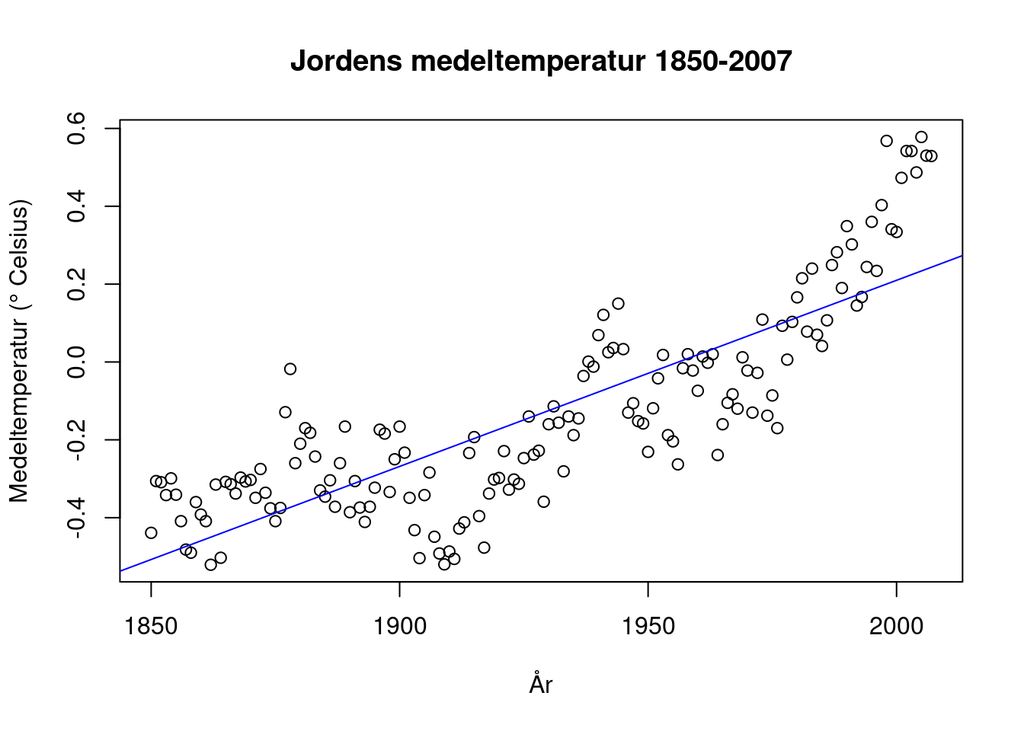

Jordens medeltempteratur 1850-2007. År på x-axeln och temperatur på y-axeln, mätt i grader Celcius. Anpassad regressionslinje i blått.

```r
plot(df$år, # Plottar datamaterialet likt tidigare
     df$temperatur,
     main = "Jordens medeltemperatur 1850-2007",
     xlab = "År",
     ylab = "Medeltemperatur (° Celsius)")
abline(modell, # Lägger till anpassad linje
       col = "blue")
```

Det är svårt att med blotta ögat avgöra hur väl linjen passar. Vi kan skönja ett mönster för de punkter som ligger utanför linjen, nämligen att det finns fler punkter *ovan* linjen ute på kanterna, dvs tidiga respektive sena årtal, medan det i mitten av datamaterialet, dvs omkring år 1900-1980, finns fler punkter *under* linjen. Detta är helt i linje med våra kommentarer ovan, att det finns en exponentiell tendens i datamaterialet, sett över hela tidsperioden.

Två hjälpmedel för att undersöka hur väl linjen passar datamaterialet är residualplot och normalfördelningsplot. Residualer mäter individuella observationers avvikelse från den anpassade linjen och residualplotten hjälper oss således att avgöra om en linjär modell är lämplig för våra data. Vi undersöker:

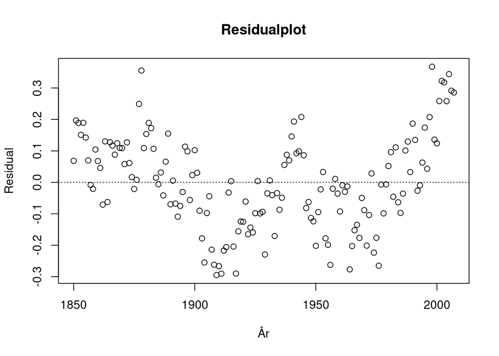

Residualplot över jordens medeltemperatur, tidigare plottad.

```r
residual <- modell$residuals # Extraherar residualer
plot(df$år, residual, # Skapar residualplot
     main = "Residualplot",
     xlab = "År",
     ylab = "Residual")
abline(a = 0, b = 0, lty = "dotted") # Lägger till horisontell linje
```

I figuren ovan kan vi skönja en trend bland residualerna. De är inte jämnt spridda, utan de första decennierna ser vi en nedåtgående trend, och de sista decennierna ser vi i stället en uppåtgående trend. Vi kan också se olika stora avvikelser från den horisontella mittlinjen för olika segment längs x-axlen. Detta är indikationer på att variansen inte är konstant, och en linjär modell kanske inte är den bästa för vårt datamaterial. Dessa kriterier för enkel linjär regression (som vi diskuterade ovan) verkar med andra ord inte helt vara uppfyllda.

Vi går vidare och betraktar en normalfördelningsplot:

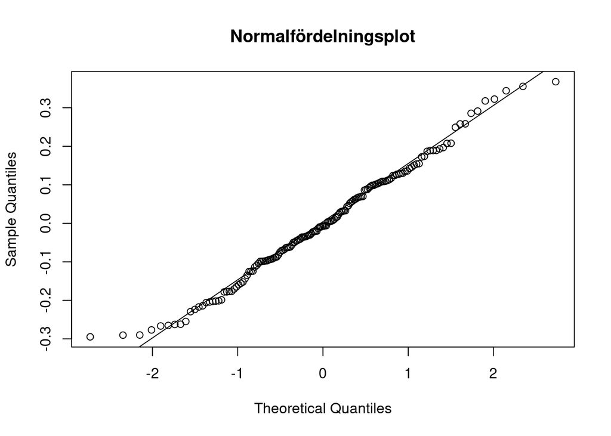

En normalfördelningsplot över residualerna från tidigare plottad linjär regression över jordens medeltemperatur.

```r
qqnorm(residual,
        main = "Normalfördelningsplot")
qqline(residual)
```

Normalfördelningsplotten säger oss hur spridningen bland residualerna är. Som tidigare nämnt vill vi att residualerna ska vara normalfördelade. I figuren ovan ser vi att de allra flesta punkterna ligger längs en rät linje, och utifrån det kan vi sluta oss till att residualerna är hyfsat normalfördelade. För att knyta an till vår tidigare diskussion om förutsättningar för enkel linjär regressoin, konstaterar vi alltså att kriteriet om normalfördelade residualer kan anses vara uppfyllt.

# Uppgift 2: Jordens medeltemperatur under tre perioder

I den här uppgiften vill vi undersöka om vi kan få vår linjära modell att passa bättre om vi i stället för att undersöka hela tidsperioden delar upp datamaterialet i mindre delperioder, nämligen 1880–1929 (period 1), 1930–1969 (period 2) och 1970–2007 (period 3).

## Uppgift 2.1

Här vill vi undersöka samma sak som i uppgift 1, samt ange punktskattningarna av nterceptet och lutningskoefficienten. Vi utgår från samma data som i uppgift 1, och använder igen `R`:s inbyggda funktion för linjär regression när vi skapar våra modeller:

```r
# Dela upp data i tre delperioder
df_1 <- subset(df, år > 1879 & år < 1930)
df_2 <- subset(df, år > 1929 & år < 1970)
df_3 <- subset(df, år > 1969)

# Skapa tre modeller, en för respektive tidsperiod
modell_1 <- lm(temperatur ~ 1 + år, data = df_1) # 1:an säger åt R att vi vill ha ett intercept
modell_2 <- lm(temperatur ~ 1 + år, data = df_2)
modell_3 <- lm(temperatur ~ 1 + år, data = df_3)
```

Vi vill undersöka för var och en av dessa tre perioder om de uppfyller förutsättningarna för enkel linjär regression. För att ta reda på detta plottar vi regressionslinje, residualplot och normalfördelningsplot för alla tre tidsperioder:

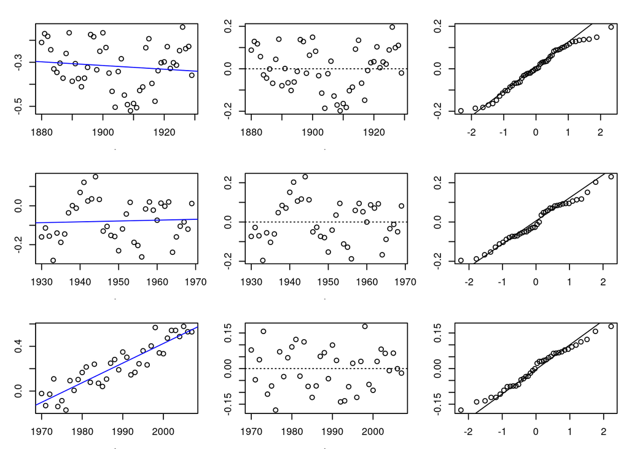

För respektive tidsperiod (rader) plottas regressionslinje (vänster kolumn), residualplott (mittenkolumn) och normalfördelningsplott (höger kolumn). Detta för alla periodindelningar 1880-1929, 1930-1969 och 1970-2007.

```r
# Set smaller margins
par(mfrow = c(3, 3), mar = c(3, 3, 2, 1))  # c(bottom, left, top, right)

# Plotta alla punkter i årsperioden över årtalen
plot(df_1$år, df_1$temperatur, xlab = "År", ylab = "Temperatur")
abline(modell_1, col = "blue")

# Plotta residualer
plot(df_1$år, modell_1$residuals, xlab = "År", ylab = "Residualer")
abline(a = 0, b = 0, lty = "dotted")

qqnorm(modell_1$residuals, main = "")
qqline(modell_1$residuals)


plot(df_2$år, df_2$temperatur, xlab = "År", ylab = "Temperatur")
abline(modell_2, col = "blue")

plot(df_2$år, modell_2$residuals, xlab = "År", ylab = "Residualer")
abline(a = 0, b = 0, lty = "dotted")

qqnorm(modell_2$residuals, main = "")
qqline(modell_2$residuals)


plot(df_3$år, df_3$temperatur, xlab = "År", ylab = "Temperatur")
abline(modell_3, col = "blue")

plot(df_3$år, modell_3$residuals, xlab = "År", ylab = "Residualer")
abline(a = 0, b = 0, lty = "dotted")

qqnorm(modell_3$residuals, main = "")
qqline(modell_3$residuals)
```

I figur 5 ser vi att period 1 och 2 inte har så bra förutsättningar för linjär regression. Residualerna är inte helt jämnt spridna, utan det går att skönja ett mönster bland dem. För period 3 däremot, ser vi en jämn spridning av residualerna, vilket är önskvärt och nödvändigt för linjär anpassning. Utifrån normalfördelningsplottarna ser vi att alla tre perioder verkar ha hyfsat normalfördelade residualer. Möjligen är period 2 lite tveksam på denna punkt men vi tycker att det är acceptabelt. Resten av förutsättningarna ärver vi från den större perioden.

Nu utför vi en enkel linjär regression på alla tre perioder, samt sparar skattningarna vi får av $\alpha$ och $\beta$ för alla tre perioder, samt $p$-värdena för alla dessa för skojs skull.

```r
sammanfattning_1 <- summary(modell_1)
sammanfattning_2 <- summary(modell_2)
sammanfattning_3 <- summary(modell_3)

alpha1 <- c(coef(sammanfattning_1)[1], coef(sammanfattning_1)[1, "Pr(>|t|)"])
beta1 <- c(coef(sammanfattning_1)[2], coef(sammanfattning_1)[2, "Pr(>|t|)"])

alpha2 <- c(coef(sammanfattning_2)[1], coef(sammanfattning_2)[1, "Pr(>|t|)"])
beta2 <- c(coef(sammanfattning_2)[2], coef(sammanfattning_2)[2, "Pr(>|t|)"])

alpha3 <- c(coef(sammanfattning_3)[1], coef(sammanfattning_3)[1, "Pr(>|t|)"])
beta3 <- c(coef(sammanfattning_3)[2], coef(sammanfattning_3)[2, "Pr(>|t|)"])

table <- data.frame(perioder = c("1880-1929", "1930-1969", "1970-2007"),
                    alpha = c(alpha1[1], alpha2[1], alpha3[1]),
                    beta = c(beta1[1], beta2[1], beta3[1]),
                    pvärdeb = c(beta1[2], beta2[2], beta3[2]))

colnames(table) <- c("Årsperiod", "alpha",
                   "beta", "p-värde för hypotesen beta = 0")

knitr::kable(table, caption = "Tabell av värden på skattningar av alpha, beta, och p-värden för betas skattningar.")
```

Tabell av värden på skattningar av alpha, beta, och p-värden för betas skattningar.

| Årsperiod | alpha | beta | p-värde för hypotesen beta = 0 |
| --- | --- | --- | --- |
| 1880-1929 | 1.2849781 | -0.0008419 | 0.4104753 |
| 1930-1969 | -0.9199713 | 0.0004318 | 0.7693833 |
| 1970-2007 | -34.6277510 | 0.0175265 | 0.0000000 |

Som vi ser i tabell 1, så är skattningarna av lutningskoefficienterna ($\beta$) rätt så usla (högt $p$-värde) för första två perioderna, vilket stärker vår uppfattning om att data för dessa två tidsperioderna inte var lämpade till linjär regression. Om vi i stället betraktar skattningarna för $\alpha$ och $\beta$ i tredje perioden ser vi att dessa var rätt så bra, eftersom vi har ett mycket lågt p-värde, nära noll (men avrundat i tabellen). Detta tar oss vidare till nästa del.

## Uppgift 2.2

Här testar vi direktörens hypotes om att det inte finns en trend mot ett varmare klimat, dvs, $H_0 : \beta \le 0$. Då blir vår alternativa hypotes $H_1 : \beta > 0$. Vi väljer att testa $\beta$ eftersom vår förklarande variabel inte är stokastisk, dvs, vi vill bara se om år (som ej är stokastisk) har en positiv effekt på medeltemperatur. Vi utför alltså ett $t$-test, eftersom vi försöker skatta en parameter $\beta$ av data, och vi vet att

$$\frac{\beta^* - \beta}{s/ \sqrt{S_{xx}}}
\sim t_{n-2}.$$

Vi väljer att utföra ett ensidigt hypotestest eftersom det ingår i direktörens påstående att det skulle till och med kunna finnas en negativ trend mellan år och temperatur, dvs, att världen blir kallare. Nollhypotesen är en så kallad sammansatt hypotes, varför vi i det här fallet bör utföra ett ensidigt test.

Går vi tillbaka till tabell 1, ser vi att $\beta$ för årsperioden $1970-2007$ är liten - dock nollskillt! Vidare har vi ett extremt litet $p$-värde från vårt $t$-test (i princip noll), som vid halvering (eftersom `summary()` endast ger ett tvåsidigt test, men detta är inte ett problem eftersom responsvariabeln är normalfördelad, dvs symmetrisk), blir ännu mindre. Detta är mindre än $0.05$, som är den signifikansnivå som angavs i instruktionerna, och därför kan vi med god säkerhet förkasta nollhypotesen, och dra slutsatsen om att det finns en *tydlig* trend mot ett varmare klimat mellan åren $1970$ och $2007$. Med andra ord hade direktören fel.

# Uppgift 3: Prediktion

I den här uppgiften vill vi utifrån givna data predicera jordens medeltemperatur framåt i tiden.

## Upgift 3.1

Vi vill generera prediktion för åren 2008-2022, och vi kommer göra detta baserat på data från olika tidsperioder. Vi kommer att utvärdera våra modeller gentemot testdata, med hjälp av roten ur medelkvadratfelet. Vi börjar därför med att definiera en funktion som ger oss medelkvadratfelet.

```r
#Funktion som ger roten ur medelkvadratfelet (RMSE) mellan predikterade och faktiska värden, roten ur för att vi ska få samma enhet, dvs vi får medelfelet av temperatur.
rmse <- function(y_faktiska, y_pred){
  diff <- y_faktiska - y_pred
  sqr_diff <- diff^2
  mse <- mean(sqr_diff)
  return(sqrt(mse))
}
```

Därefter läser vi in de faktiska värdena för perioden $2008-2022$, så att vi har något att jämföra med.

```r
# Låt period 1 ("p1") beteckna årsindelningen 2008-2022,
# och period 2 ("p2") beteckna 1970-2007.
# Vidare betecknar "hela", årsperioden 1850-2007

test_df <- read.csv("temperatur_test.csv", header = TRUE)

x_p1 <- test_df$år # sekvens med åren 2007-2022

df_p1 <- data.frame(år = x_p1)  # Vi gör en dataframe med åren som vi kan använda oss av
```

Nu är vi redo att göra lite prediktioner! Vi vill först ställa upp två prediktionsmodeller för åren 2008-2022. Den ena modellen ska baseras på data från 1850-2007 och den andra baseras på data från tidsperioden 1970-2007.

```r
# Prediktionsmodell för 2008-2022 (p1) baserat på 1850-2007 (hela)
prediktion_hela_p1 <- predict(modell, newdata = df_p1, interval = 'predict')

# Plocka ut prediktioner samt gränser på prediktionsintervallet'
y_pred_hela_p1 <- prediktion_hela_p1[, 1]

#Prediktionsmodell för 2008-2022 (p1) baserat på 1970-2007 (p2)
prediktion_p2_p1 <- predict(modell_3, newdata = df_p1,
                             interval = 'predict')

y_pred_p2_p1 <- prediktion_p2_p1[, 1]
pinterval_undre_p1 <- prediktion_p2_p1[, 2]
pinterval_övre_p1 <- prediktion_p2_p1[, 3]
```

Nu vill vi predicera medeltemperaturen för åren 1970-2007. Även denna gång vill vi göra två modeller. Den ena modellen baseras på data för tidsperioden 1850-2007 (hela) och den andra modellen baseras på data från åren 1970-2007 (dvs exakt samma år som vi vill predicera).

```r
# Här gör vi prediktionerna som ovan, fast av perioden 1970 - 2007 (p2)
x_p2 <- df_3$år

df_p2 <- data.frame(år = x_p2)

#Prediktionsmodell för 1970-2007 (p2), baserat på 1850-2007 (hela)
prediktion_hela_p2 <- predict(modell, newdata = df_p2, interval = 'predict')

y_pred_hela_p2 <- prediktion_hela_p2[, 1]

#Prediktionsmodell för 1970-2007 (p2), baserat på 1970-2007 (p2)
prediktion_p2_p2 <- predict(modell_3, newdata = df_p2, interval = 'predict')

y_pred_p2_p2 <- prediktion_p2_p2[, 1]
```

Nu har vi gjort våra prediktioner och vi är redo att utvärdera modellerna med hjälp av vår tidigare definierade funktion för att beräkna roten ur medelkvadratfelet. Vi samlar våra resultat i en tabell.

```r
y_faktiska_p1 <- test_df$temperatur

rmse_hela_p1 <- rmse(y_faktiska_p1, y_pred_hela_p1)
rmse_p2_p1 <- rmse(y_faktiska_p1, y_pred_p2_p1)


y_faktiska_p2 <- df_3$temperatur

rmse_hela_p2 <- rmse(y_faktiska_p2, y_pred_hela_p2)
rmse_p2_p2 <- rmse(y_faktiska_p2, y_pred_p2_p2)

table2 <- data.frame(
  anpassning = c("1850 - 2007", "1970 - 2007", "1850 - 2007", "1970 - 2007"),
  pred = c("2008 - 2022", "2008 - 2022", "1970 - 2007", "1970 - 2007"),
  rmse_värden = c(rmse_hela_p1, rmse_p2_p1, rmse_hela_p2, rmse_p2_p2)
)

colnames(table2) <- c("Modell baserad på", "Prediktioner för", "RMSE")
knitr::kable(table2, caption = "Tabell med RMSE för olika modeller och deras prediktioner")
```

Tabell med RMSE för olika modeller och deras prediktioner

| Modell baserad på | Prediktioner för | RMSE |
| --- | --- | --- |
| 1850 - 2007 | 2008 - 2022 | 0.5377942 |
| 1970 - 2007 | 2008 - 2022 | 0.1506799 |
| 1850 - 2007 | 1970 - 2007 | 0.1788645 |
| 1970 - 2007 | 1970 - 2007 | 0.0878726 |

Vi noterar några saker från tabell 2. Först noterar vi att prediktionerna för medeltemperaturen åren 2008-2022 görs bäst av modellen med data från den tidsperioden 1970-2007. Detta styrker vår idé om att hela perioden är dålig för linjära anpassningar.

Ytterligare något vi noterar är att när en modell predikterar samma värden som den utgörs av, får vi ett väldigt litet, (men ändå nollskillt!) RMSE. Men ännu en grej som får oss att tycka att vår allra första modell är dålig som en linjär regressionsmodell, är att när den försöker predicera en delmängd av årperioden som den utgörs av, så lyckas den *sämre* (dvs får ett högre RMSE), än modellen utifrån åren 1970-2007 lyckas med på helt nya värden!

Vi konstaterar att det inte alltid är bättre att modellanpassa på en större datamängd. Tvärtom ser vi när vi jämför våra prediktioner att det är modellerna baserade på åren 1970-2007 som lyckas bättre i att predicera här.

Med detta sagt, är det fortfarande rätt stora fel vi finner, (som även figur 6 nedan delvis säger oss). Även om talen är små är det värt att påminna läsaren att det vi undersöker är rätt så små temperaturskillnader, så ett snittligt fel på ca $0.15$ är rätt så stort när man tänker på att datan vi undersöker har skillnader i temperatur så små som $0.05$ (t.ex. mellan åren $1985$ till $1986$).

## Uppgift 3.2

I den här uppgiften vill vi utvärdera våra prediktioner ytterligare. Vi plottar de predicerade värdena för 2008-2022, inklusive preditionsintervall, samt de faktiska värdena på medeltemperaturen för samma år.

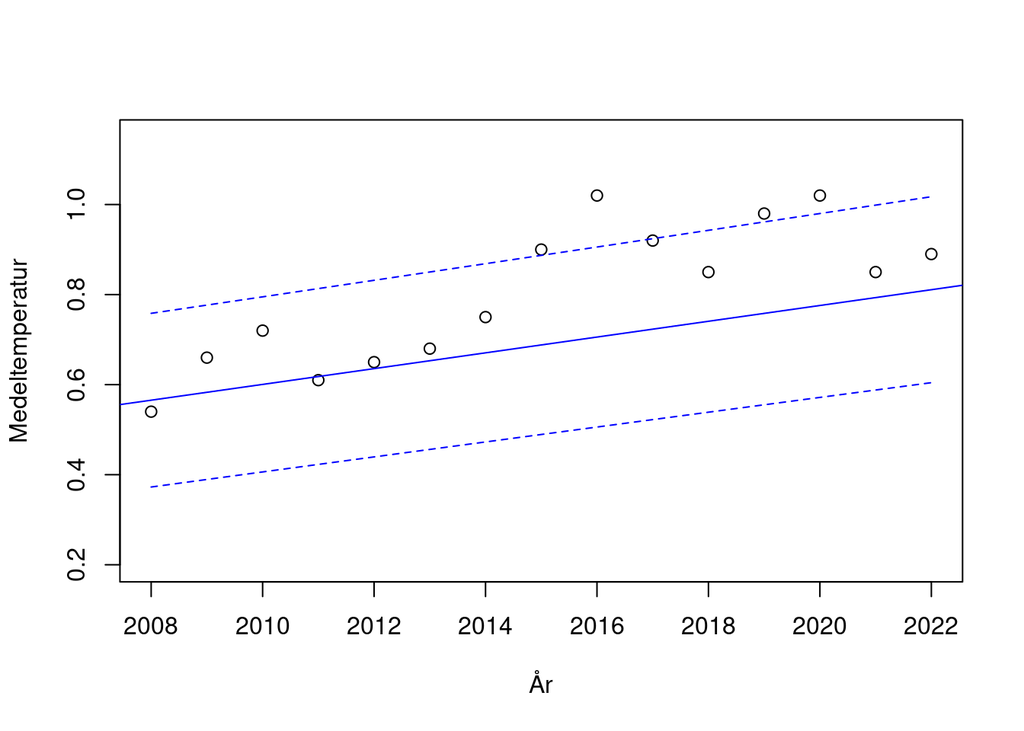

```r
#Plottar predicerade värden tillsammans med prediktionsintervall
plot(x_p1, y_faktiska_p1, ylim = c(0.2, 1.15),
     xlab = "År",
     ylab = "Medeltemperatur")

lines(x_p1, pinterval_undre_p1, col = "blue",
      lty = "dashed")
lines(x_p1, pinterval_övre_p1, col = "blue",
      lty = "dashed")
abline(modell_3, col = "blue")
```

Förmodligen är inte enkel linjär anpassning den bästa modellen för våra data. Vi tittar endast på en (1) förklarande variabel som är högst otrolig att kunna omfamna alla faktorer som går in i något så komplext som temperatur. Vidare ser vi i figur 6 att flera av de faktiska punkterna ligger utanför prediktionsintervallet. I synnerhet sker detta under den *senare halvan* av tidsintervallet. Detta är en indikation på att ökningen i temperatur inte verkar ha ökat linjärt på senaste tiden, utan snabbare än så (kanske exponentiellt, men detta vet vi inget om). Linjaritet är inte givet heller längre in i framtiden.

Nu vet vi inte hur långt ifrån kursinnehållet vi går, men ett sätt att förbättra modellen är att man t.ex. hade kunnat lägga till fler förklarande variabler som en del av modellen. T.ex. genom att titta på det snittliga koldioxid-halten i atmosfären per år. Ett annat förslag är att helt enkelt inte anpassa en linjär modell, utan kanske en exponentiell. Det hade åtminstone varit intressant att undersöka och jämföra vilken av de modellerna som vore bäst för de faktiska värdena.

Något som är problematiskt med att predicera värden i framtiden på det här sättet är att ett stort antagande görs, nämligen att vi antar att allt som sker i världen hålls konstant. Det finns inte alltid bra skäl att tro att så är fallet. Som vi har sett med t.ex. nya teknologier genom tiderna så har dessa lett till en stor ökning av koldioxidutsläpp efter industriella revolutionen, och detta kan ju även hända igen (om det inte redan har hänt). Dessa kan ha en effekt på globala temperaturen som inte fångas upp av en sån enkel modell som vår.